# NewmanOmics: Tools for Personalized Transcriptomics

Kevin R. Coombes

In this vignette, we describe how to use the NewmanOmics Paired and Banked tests to analyze gene expression data from a single sample.

# Getting Started

As usual, we start by loading the package:

```r
library(NewmanOmics)
```

The package contains paired tumor and normal samples from patients with head and neck cancer. these came from a study that was submitted to the Gene Expression Omnibus.

```r
data(GSE6631)
dim(GSE6631)
```

```
## [1] 2000   44
```

```r
GSE6631[1:5, 1:4]
```

```
##            Normal.mucosa.1  Cancer.1 Normal.mucosa.2  Cancer.2
## 34155_s_at        26.42586  22.19725        22.13673  18.66223
## 34281_at         334.29232 382.92879       393.40014 509.30754
## 39125_at         258.62695 290.06060       268.97994 220.16837
## 37276_at          45.65556  38.86692        34.77368  33.40627
## 1519_at          423.26690 366.40731       308.62338 550.34888
```

As we can see, this consists of (normalized) Affymetrix microarray data. The odd numbered columns are derived from normal mucosa, and the even numbered columns are derived from paired tumor samples.

Before proceeding, we are going to log-transform the data.

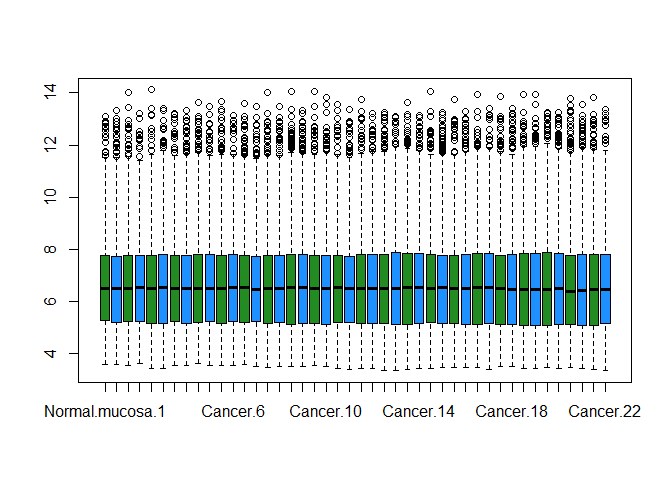

```r
HN <- log2(1 + GSE6631)
boxplot(HN, col=c("forestgreen", "dodgerblue"))
```

The figure suggests that the the data have been reasonably normalized, and that it is unlikely to be overwhelmed by artifacts.

# Paired Statistic

To illustrate the Newman Paired test, we are going to use only one sample.

```r
HN1 <- HN[, 1:2]
result1 <- pairedStat(HN1, pairing = c(-1,1))
summary(result1@nu.statistics)
```

```
##     Cancer.1
##  Min.   : 0.000584
##  1st Qu.: 0.415834
##  Median : 0.988511
##  Mean   : 1.417227
##  3rd Qu.: 1.834846
##  Max.   :17.437729
```

```r
summary(result1@p.values)
```

```
##     Cancer.1
##  Min.   :0.0000
##  1st Qu.:0.3003
##  Median :0.5769
##  Mean   :0.5462
##  3rd Qu.:0.8143
##  Max.   :0.9997
```

We can create a histogram of the per-gene (empirical) p-values

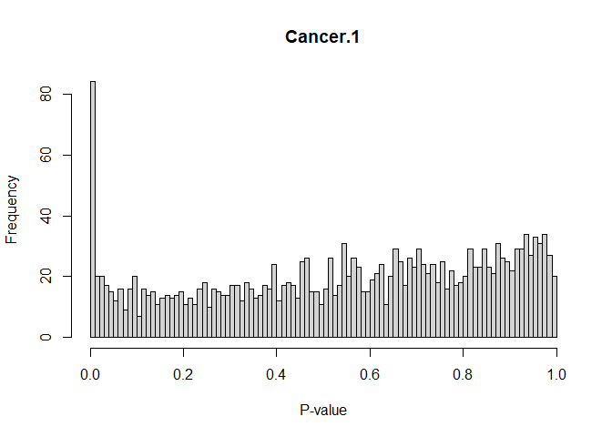

```r
hist(result1)
```

We can also produce an “M-versus-A” plot of the data.

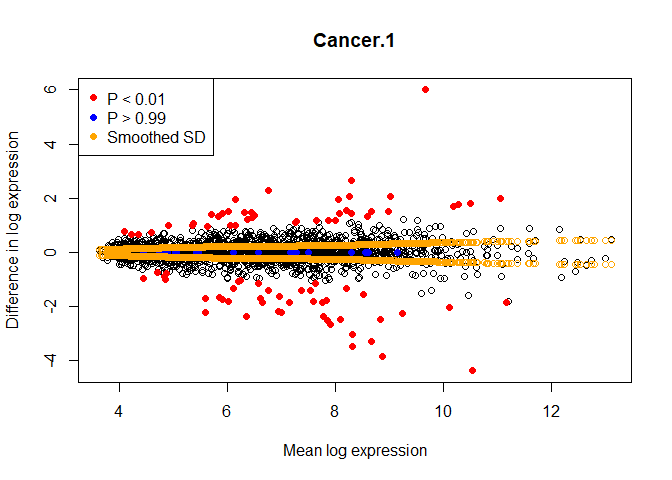

Bland-Altman plot.

```r
plot(result1)
```

## Alternate Inputs

The `pairedStat` function has flexible inputs, allowing you to store the data in various ways. Here we run the algorithm for three pairs, with an explicit pairing vector.

```r
result2 <- pairedStat(HN[, 1:6], pairing=c(-1, 1, -2, 2, -3, 3))
summary(result2@nu.statistics)
```

```
##     Cancer.1            Cancer.2            Cancer.3
##  Min.   : 0.000584   Min.   : 0.000984   Min.   : 0.001682
##  1st Qu.: 0.415834   1st Qu.: 0.459064   1st Qu.: 0.369775
##  Median : 0.988511   Median : 1.020574   Median : 0.878206
##  Mean   : 1.417227   Mean   : 1.417032   Mean   : 1.419570
##  3rd Qu.: 1.834846   3rd Qu.: 1.779653   3rd Qu.: 1.765563
##  Max.   :17.437729   Max.   :15.264180   Max.   :16.572431
```

```r
summary(result2@p.values)
```

```
##     Cancer.1         Cancer.2         Cancer.3
##  Min.   :0.0000   Min.   :0.0000   Min.   :0.0000
##  1st Qu.:0.3004   1st Qu.:0.3152   1st Qu.:0.3191
##  Median :0.5765   Median :0.5643   Median :0.6201
##  Mean   :0.5462   Mean   :0.5374   Mean   :0.5629
##  3rd Qu.:0.8140   3rd Qu.:0.7954   3rd Qu.:0.8343
##  Max.   :0.9997   Max.   :0.9995   Max.   :0.9992
```

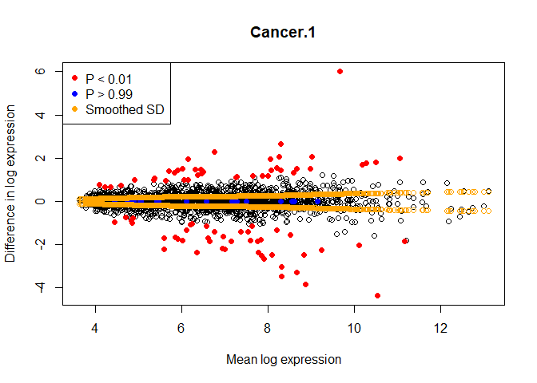

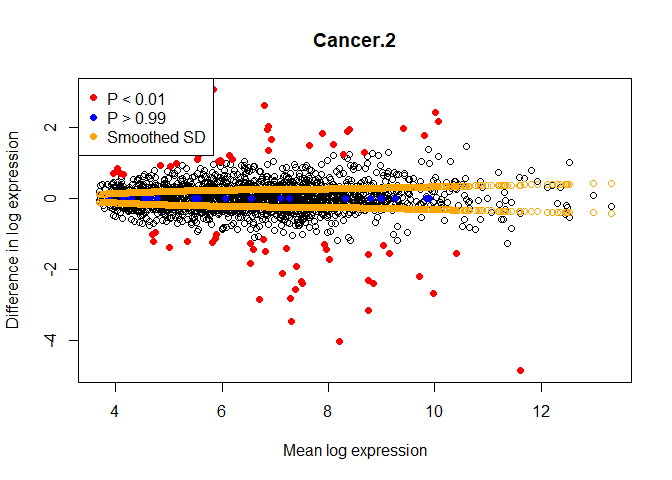

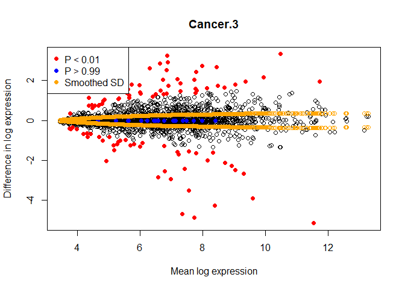

```r
plot(result2)
```

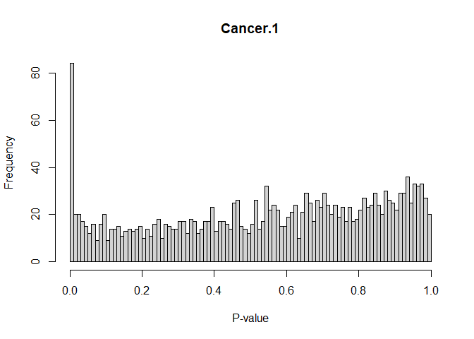

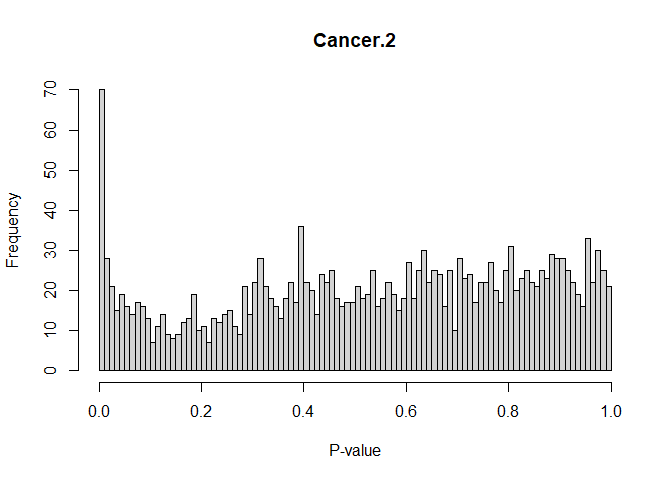

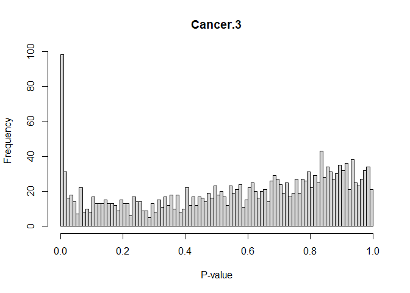

```r
hist(result2)
```

We can also input the same data as a pair of matrices.

```r
normals <- HN[, c(1,3,5)]
tumors <- HN[, c(2,4,6)]
result3 <- pairedStat(normals, tumors)
summary(result3@nu.statistics)
```

```
##     Cancer.1            Cancer.2            Cancer.3
##  Min.   : 0.000584   Min.   : 0.000984   Min.   : 0.001682
##  1st Qu.: 0.415834   1st Qu.: 0.459064   1st Qu.: 0.369775
##  Median : 0.988511   Median : 1.020574   Median : 0.878206
##  Mean   : 1.417227   Mean   : 1.417032   Mean   : 1.419570
##  3rd Qu.: 1.834846   3rd Qu.: 1.779653   3rd Qu.: 1.765563
##  Max.   :17.437729   Max.   :15.264180   Max.   :16.572431
```

```r
summary(result3@p.values)
```

```
##     Cancer.1         Cancer.2         Cancer.3
##  Min.   :0.0000   Min.   :0.0000   Min.   :0.0000
##  1st Qu.:0.3011   1st Qu.:0.3159   1st Qu.:0.3197
##  Median :0.5769   Median :0.5648   Median :0.6199
##  Mean   :0.5463   Mean   :0.5375   Mean   :0.5629
##  3rd Qu.:0.8141   3rd Qu.:0.7951   3rd Qu.:0.8345
##  Max.   :0.9997   Max.   :0.9996   Max.   :0.9993
```

Or we can input the same data as a list of paired samples.

```r
listOfPairs <- list(HN[,1:2], HN[,3:4], HN[,5:6])
result4 <- pairedStat(listOfPairs)
summary(result4@nu.statistics)
```

```
##     Cancer.1            Cancer.2            Cancer.3
##  Min.   : 0.000584   Min.   : 0.000984   Min.   : 0.001682
##  1st Qu.: 0.415834   1st Qu.: 0.459064   1st Qu.: 0.369775
##  Median : 0.988511   Median : 1.020574   Median : 0.878206
##  Mean   : 1.417227   Mean   : 1.417032   Mean   : 1.419570
##  3rd Qu.: 1.834846   3rd Qu.: 1.779653   3rd Qu.: 1.765563
##  Max.   :17.437729   Max.   :15.264180   Max.   :16.572431
```

```r
summary(result4@p.values)
```

```
##     Cancer.1         Cancer.2         Cancer.3
##  Min.   :0.0000   Min.   :0.0000   Min.   :0.0000
##  1st Qu.:0.3011   1st Qu.:0.3157   1st Qu.:0.3195
##  Median :0.5773   Median :0.5651   Median :0.6204
##  Mean   :0.5464   Mean   :0.5376   Mean   :0.5631
##  3rd Qu.:0.8147   3rd Qu.:0.7957   3rd Qu.:0.8350
##  Max.   :0.9997   Max.   :0.9996   Max.   :0.9993
```

# Banked Statistic

A completely different approach to personalized transcriptomics is to compare individual samples to a “bank” of known normals.

```r
normals <- HN[, seq(1, ncol(HN), 2)] # odds are normal
tumors <- HN[, seq(2, ncol(HN), 2)] # evens are tumor
bank <- createBank(normals)
result5 <- bankStat(bank, tumors[,1,drop=FALSE])
summary(result5$nu.statistics)
```

```
##     Cancer.1
##  Min.   :-9.6255
##  1st Qu.:-0.5540
##  Median : 0.2797
##  Mean   : 0.1027
##  3rd Qu.: 0.9911
##  Max.   : 6.7524
```

```r
summary(result5$p.values)
```

```
##     Cancer.1
##  Min.   :0.0000
##  1st Qu.:0.2898
##  Median :0.6101
##  Mean   :0.5569
##  3rd Qu.:0.8392
##  Max.   :1.0000
```

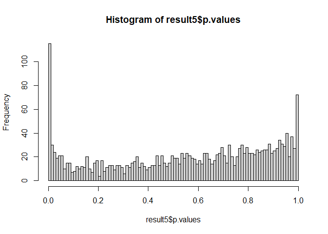

```r
hist(result5$p.values, breaks=101)
```